# Proyección de la matrícula de la Universidad de Puerto Rico por recinto

## Los datos: archivos sistémicos de la UPR

100

archivos CSV: 10 recintos × 10 años académicos (2017-18 a 2026-27)

734,081

registros: un estudiante en una sesión académica de un recinto

88

variables por registro, iguales en todos los archivos

1

identificador por estudiante, común a todos los recintos y años

#### Qué es una fila

Un estudiante matriculado en una sesión académica (agosto, enero o verano) de un año, en un recinto. Un estudiante que cursa todo el año aparece dos o tres veces en el archivo de ese año, una por sesión.

Los archivos vienen en formato largo, con dos columnas (variable y valor): cada 88 filas consecutivas forman un registro.

#### Ejemplo de registro

Identifier ···7F2A Location UPR en Río Piedras Academic Year 2024-2025 Academic Period Number 1 (agosto) Degree Level Bachillerato Classification Tercer Nivel Registration Type Activo Credits 15 School Type Pública First Academic Year 2022-2023 Degrees Awarded 0

Fuente: Universidad de Puerto Rico, datos sistémicos de matrícula por recinto y año académico (portal Power BI). [app.powerbi.com — Datos sistémicos de la UPR](https://app.powerbi.com/view?r=eyJrIjoiZDFhMzgzMjktNDU1YS00M2U1LTg4MWEtYWEwNDIxOWVkNThmIiwidCI6IjBkZmE1ZGMwLTAzNmYtNDYxNS05OWU0LTk0YWY4MjJmMmI4NCIsImMiOjF9)

## Los datos: variables y enlace entre años

#### Las 88 variables

**Sesión y recinto:** Location, Academic Year, Academic Session Code, Academic Period Number.

**Programa y nivel:** College, Major, Degree Level, CIP, Classification, Registration Type, FullPart Time.

**Rendimiento:** Credits, Term GPA, Career Earned Hours, Career GPA, Degrees Awarded.

**Admisión y procedencia:** School, School Type, School City, School Gpa, IGS, Admitted Location, Admitted Academic Year.

**Sociodemográficas:** Sex, Age, City Of Residence, Household Income, Father/Mother Education, Pell Disb.

**Trayectoria:** Identifier, First Academic Year, Last Academic Year, Activity Years, CohortAcademicYear.

#### Cómo se enlazan los años

El identificador es el mismo en todos los archivos: mientras el estudiante siga matriculado, aparece en el archivo del año siguiente.

**2023-24**···7F2A  
Segundo nivel

→UGPR₂

**2024-25**···7F2A  
Tercer nivel

→UGPR₃

**2025-26**···7F2A  
Cuarto nivel

Así se observa, estudiante por estudiante, el paso de un año académico de estudio al siguiente, para cada cohorte de nuevo ingreso, cuántos siguen matriculados cada año.

Un estudiante aparece desde su primer año hasta su último año matriculado, sea por graduación o por salida. Si se traslada a otro recinto o pasa a posgrado, sigue apareciendo con el mismo identificador; si se va y regresa, reaparece como readmisión.

## Modelo y estado del trabajo

**Proyecciones K-12**Pública y privada (GPR)

→

**Graduados de grado 12**\(\mathrm{Graduados}_{12,t}\)

→

**Capture Rate**Paso 1  
Completado

→

**First Year**Paso 2  
Completado

→

**UGPR**Paso 3  
Completado

→

**Cohortes y Enrollment**Pasos 4 y 5  
En proceso

### Grado 12

Matrícula pública (DEPR, 2008-09 a 2025-26) y privada (CEPR, 2006-07 a 2023-24); proyección del informe de escolaridad hasta 2050-51.

### Datos sistémicos de la UPR

734,081 registros estudiante-sesión (agosto, enero o verano), 2017-18 a 2026-27. Mes de referencia: agosto. Recintos: Aguadilla, Arecibo, Bayamón, Carolina, Cayey, Ciencias Médicas, Humacao, Ponce, Río Piedras y Utuado.

Horizonte de la proyección: de agosto de 2026 a agosto de 2051, por recinto y para el total de recintos.

## Notación

[output not shown]

Departamento de Estado de Puerto Rico, Oficina de Registro y Licenciamiento de Instituciones de Educación. (2025). *Compendio estadístico sobre la educación básica (PK-12) privada de Puerto Rico: Año académico 2023-24* [Tablas 7 y 9]. http://www.agencias.pr.gov/agencias/cepr/inicio/

National Center for Education Statistics. (2024). Table 219.20. Public high school graduates, by region, state, and jurisdiction: Selected school years, 1980-81 through 2022-23. En *Digest of Education Statistics 2024*. U.S. Department of Education. https://nces.ed.gov/programs/digest/d24/tables/dt24_219.20.asp

## Paso 1. Capture Rate

\[ \mathrm{CaptureRate}_{r,t} = \frac{\mathrm{FirstYear}_{r,t}}{\mathrm{Graduados}_{12,t}}, \qquad \mathrm{CaptureRate}_{r} = \frac{1}{5}\sum_{j=0}^{4} \mathrm{CaptureRate}_{r,\,t-j} \]

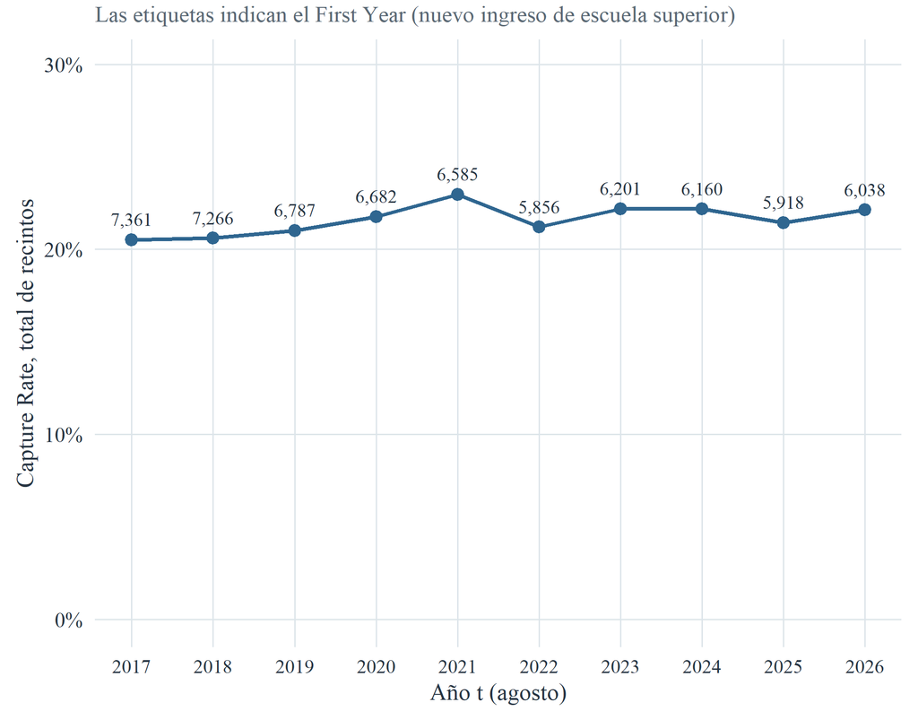

Capture Rate promedio 2021–2025, por sector de la escuela de procedencia

| Recinto | Total | Esc. pública | Esc. privada |
| --- | --- | --- | --- |
| Aguadilla | 1.82 % | 1.84 % | 1.61 % |
| Arecibo | 2.31 % | 2.29 % | 2.19 % |
| Bayamón | 2.49 % | 1.69 % | 4.01 % |
| Carolina | 2.38 % | 1.82 % | 3.38 % |
| Cayey | 1.80 % | 1.54 % | 2.23 % |
| Humacao | 2.22 % | 2.26 % | 1.98 % |
| Ponce | 2.17 % | 1.93 % | 2.51 % |
| Río Piedras | 6.46 % | 4.02 % | 11.07 % |
| Utuado | 0.34 % | 0.36 % | 0.24 % |
| Total de recintos | 21.99 % | 17.76 % | 29.21 % |

## Paso 2. First Year proyectado

\[ Y_{1,r,t} = \mathrm{Graduados}_{12,t} \times \mathrm{CaptureRate}_{r} \]

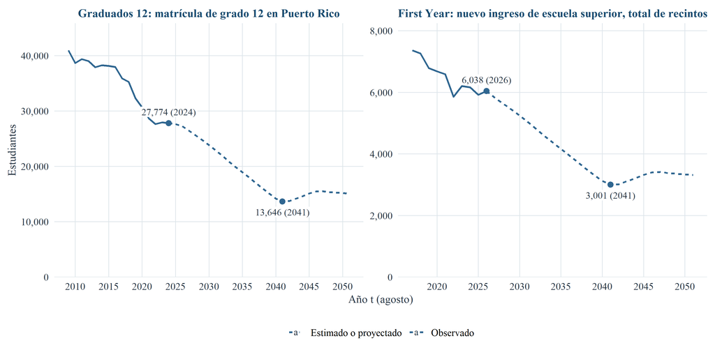

## Paso 3. Grade Progression Ratios universitarios

\[ UGPR_{k,r} = \frac{Y_{k+1,r,t+1}}{Y_{k,r,t}}, \quad k = 1, 2, 3 \]

\[ UGPR_{4,r} = \frac{Y_{4,r,t+1}}{Y_{4,r,t}} \]

\(UGPR_{4,r}\): permanencia en cuarto año o más.

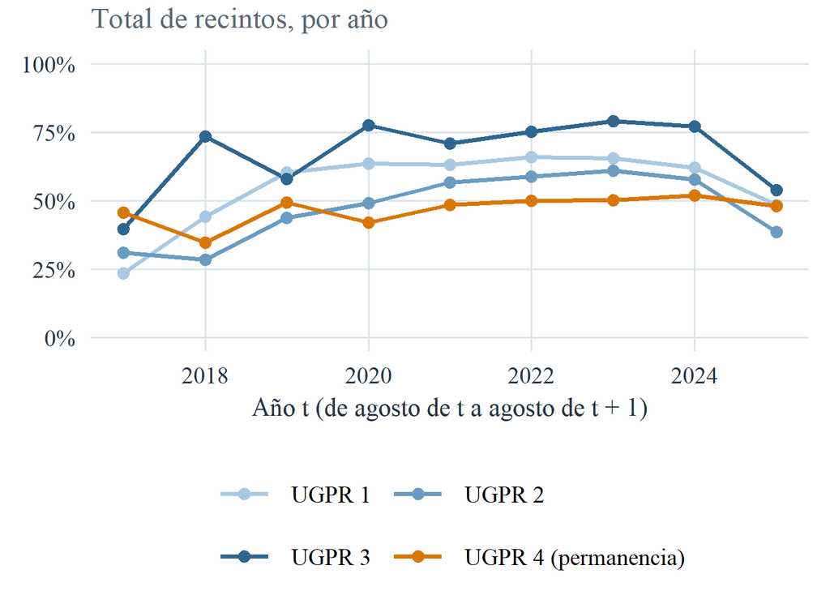

\(UGPR_{k,r}\): promedio de las transiciones 2022 a 2025 (de agosto de \(t\) a agosto de \(t+1\))

| Recinto | \(UGPR_1\) | \(UGPR_2\) | \(UGPR_3\) | \(UGPR_4\) |
| --- | --- | --- | --- | --- |
| Aguadilla | 66 % | 58 % | 69 % | 47 % |
| Arecibo | 56 % | 58 % | 77 % | 45 % |
| Bayamón | 58 % | 48 % | 71 % | 54 % |
| Carolina | 64 % | 60 % | 68 % | 27 % |
| Cayey | 52 % | 53 % | 80 % | 59 % |
| Humacao | 64 % | 61 % | 82 % | 52 % |
| Ponce | 67 % | 59 % | 77 % | 46 % |
| Río Piedras | 72 % | 62 % | 77 % | 52 % |
| Utuado | 54 % | 38 % | 62 % | 36 % |
| Total de recintos | 64 % | 59 % | 76 % | 50 % |

## Paso 4. Proyección de las cohortes universitarias

\[ \begin{aligned} Y_{1,r,t} &= \mathrm{Ingresos}_{r,t}, \qquad Y_{k+1,r,t} = Y_{k,r,t-1} \times UGPR_{k,r}, \quad k = 1, 2 \\ Y_{4,r,t} &= Y_{3,r,t-1} \times UGPR_{3,r} + Y_{4,r,t-1} \times UGPR_{4,r} \end{aligned} \]

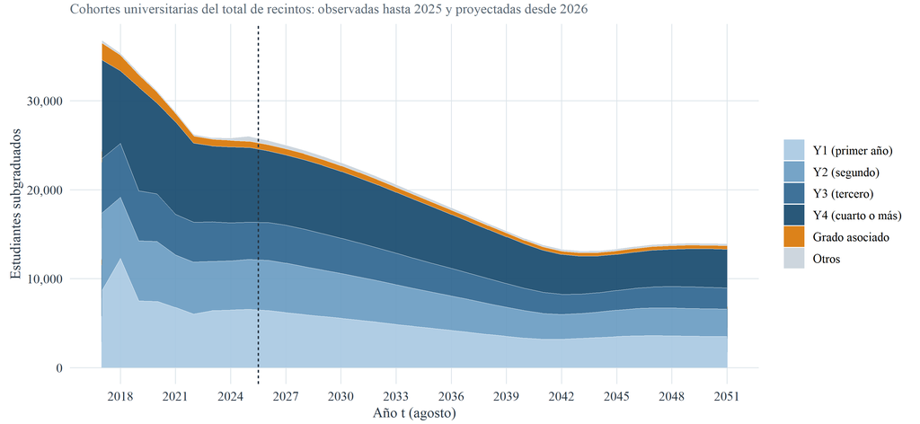

## Paso 5. Enrollment por recinto

\[ \mathrm{Enrollment}_{r,t} = Y_{1,r,t} + Y_{2,r,t} + Y_{3,r,t} + Y_{4,r,t} \]

Proyección: mediana de 2,000 simulaciones en las que \(\mathrm{CaptureRate}_r\) y \(UGPR_{k,r}\) varían según su variación histórica. Sombreado: el 90 % central de las simulaciones (percentiles 5 a 95).

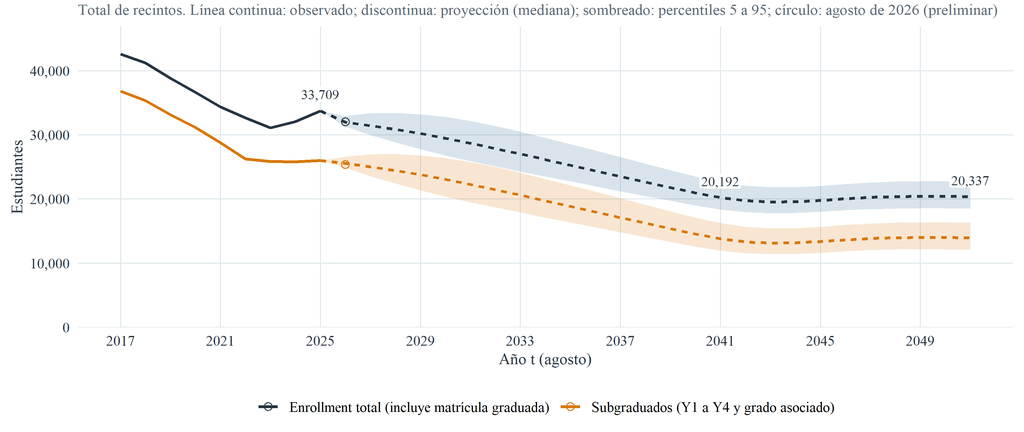

## Validación: proyección a un año

Se proyecta la matrícula subgraduada de un año usando solo la información de los años anteriores y se compara con la observada. Error = (proyectado − observado) / observado; negativo: la proyección quedó por debajo de lo observado.

-3.8 %

Total de recintos, 2025-26: proyectado con datos hasta 2024-25

0.9 %

Total de recintos, 2026-27 (preliminar): proyectado con datos hasta 2025-26

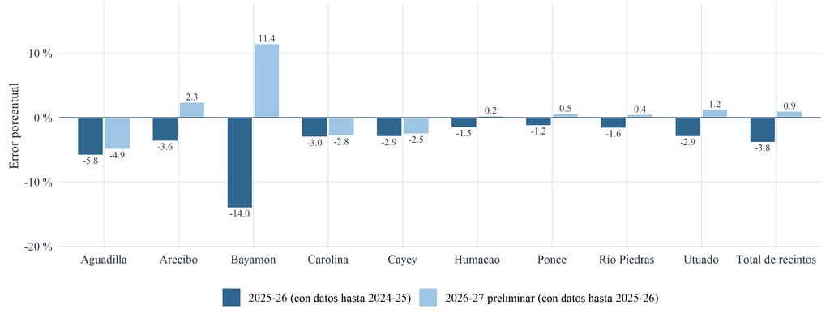

## Resultados por recinto

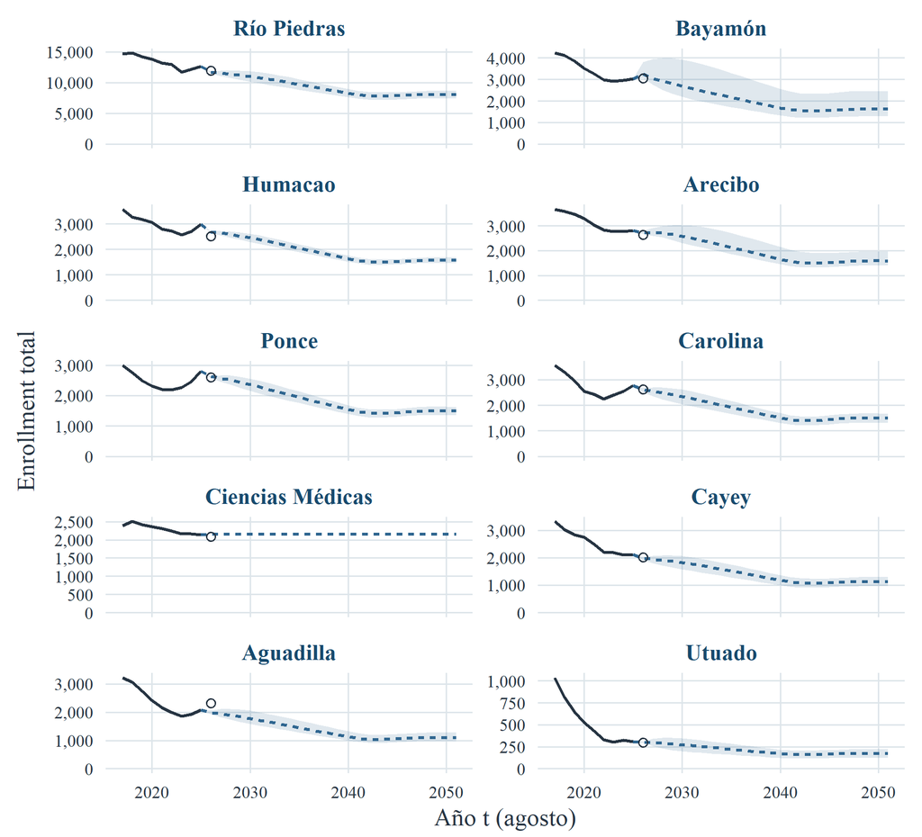

Enrollment total proyectado (mediana). Cambio: 2041-42 frente a 2025-26

| Recinto | 2025-26 | 2041-42 | 2051-52 | Cambio |
| --- | --- | --- | --- | --- |
| Río Piedras | 12,652 | 8,035 | 8,042 | -36 % |
| Bayamón | 3,031 | 1,597 | 1,615 | -47 % |
| Humacao | 2,996 | 1,562 | 1,571 | -48 % |
| Arecibo | 2,815 | 1,569 | 1,578 | -44 % |
| Ponce | 2,803 | 1,471 | 1,493 | -48 % |
| Carolina | 2,768 | 1,441 | 1,492 | -48 % |
| Ciencias Médicas | 2,143 | 2,157 | 2,157 | +1 % |
| Cayey | 2,118 | 1,121 | 1,122 | -47 % |
| Aguadilla | 2,076 | 1,076 | 1,097 | -48 % |
| Utuado | 307 | 162 | 171 | -47 % |
| Total de recintos | 33,709 | 20,192 | 20,337 | -40 % |

Línea discontinua: proyección (mediana de las simulaciones). Sombreado: 90 % central de las simulaciones (percentiles 5 a 95). Círculo: matrícula observada en agosto de 2026, dato preliminar.

## Avance y próximos pasos

### Completado

- Paso 1: tasa de captación de cada recinto, por sector de la escuela de procedencia.
- Paso 2: nuevo ingreso proyectado hasta 2051 con la serie de grado 12.
- Paso 3: UGPR de cada recinto, siguiendo a cada estudiante de un año al siguiente.

### Pendiente

- Validar con el grupo proyecciones de matrícula en el sistema UPR, los Pasos 4 y 5 de la metodología.
- Escenarios bajo y alto: repetir la proyección escolar con las variantes baja y alta de la proyección de población y correr el mismo modelo con los graduados P5 y P95.
- Mayagüez: incorporar sus datos (Oficina de Admisiones).
- Acordar con el equipo qué años se promedian en la tasa de captación y en los UGPR.
- Informe técnico con las tablas por recinto.